# Permutation Examples

Notes

Last updated: November 10, 2022 at 12:16:00 PM

# 1 Opportunity Cost

As you saw in the DataCamp video, we are interested in whether the treatment and control groups were equally likely to buy a DVD after reading the experimental statments.

```r
library(tidyverse)
library(infer)
head(opportunity)
```

```
  decision   group
1   buyDVD control
2   buyDVD control
3   buyDVD control
4   buyDVD control
5   buyDVD control
6   buyDVD control
```

```r
opportunity %>%
  count(decision, group)
```

```
  decision     group  n
1   buyDVD   control 56
2   buyDVD treatment 41
3 nobuyDVD   control 19
4 nobuyDVD treatment 34
```

```r
# or
table(opportunity$decision, opportunity$group)
```

```
           control treatment
  buyDVD        56        41
  nobuyDVD      19        34
```

```r
# or
xtabs(~decision + group, data = opportunity)
```

```
          group
decision   control treatment
  buyDVD        56        41
  nobuyDVD      19        34
```

- For each experimental group, find the proportion who bought a DVD.

```r
opportunity %>%
  group_by(group) %>%
  summarize(buy_prop = mean(decision == "buyDVD")) -> propDVD
propDVD
```

```
# A tibble: 2 × 2
  group     buy_prop
  <fct>        <dbl>
1 control      0.747
2 treatment    0.547
```

```r
# or
prop.table(xtabs(~decision + group, data = opportunity), 2)
```

```
          group
decision     control treatment
  buyDVD   0.7466667 0.5466667
  nobuyDVD 0.2533333 0.4533333
```

```r
prop.table(xtabs(~decision + group, data = opportunity), 2)[1, ]
```

```
  control treatment
0.7466667 0.5466667
```

## 1.1 Plotting opportunity cost

Again, interest is in whether the treatment and control groups were equally likely to buy a DVD after reading the experimental statements. Here, you’ll create a barplot to visualize the difference in proportions between the treatment and control groups.

- Using the `opportunity` dataset, plot `group` `fill`ed by `decision`.
- Call `geom_bar()` to add a bar plot layer, setting the position to `"fill"` to compare the relative frequencies. Note that fill should be devined by the `decision` for each group.

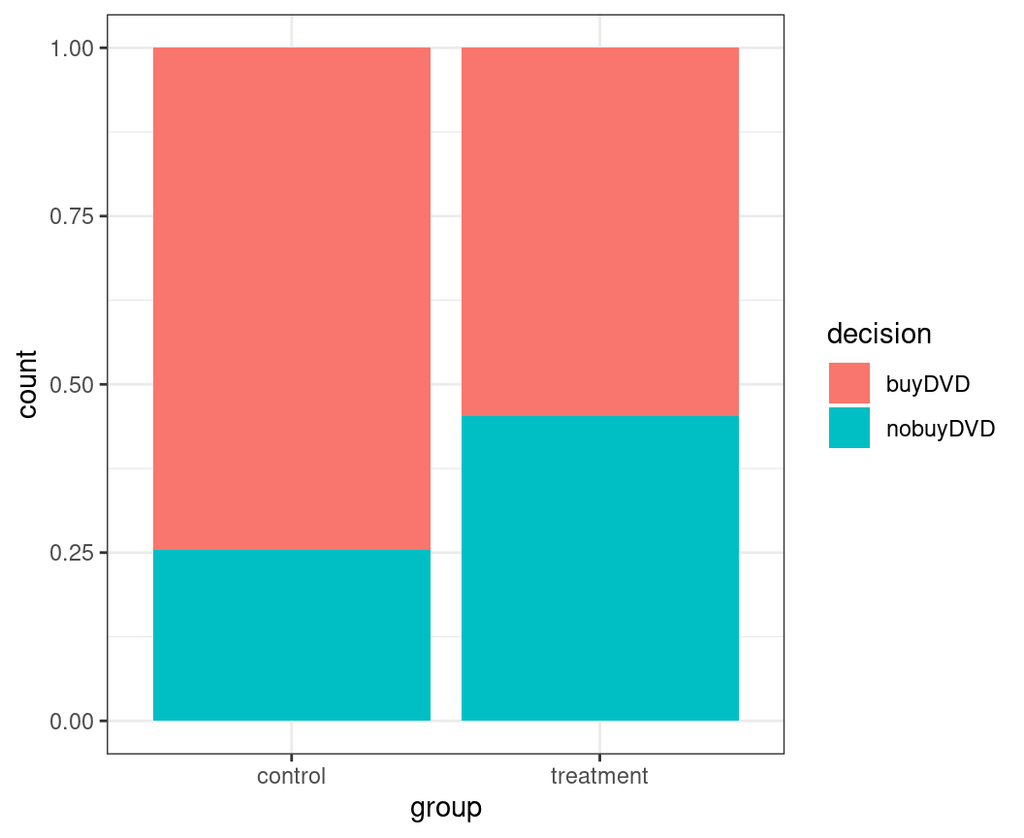

```r
ggplot(opportunity, aes(x = group, fill = decision)) +
  geom_bar(position = "fill") +
  theme_bw()
```

## 1.2 Randomizing opportunity cost

As in the previous chapter, you will permute the data to generate a distribution of differences as if the null hypothesis were true.

In the study, the number of individuals in each of the control and treatment groups is fixed. Additionally, when you assume that the null hypothesis is true—that is, the experiment had no effect on the outcome of buying a DVD—it is reasonable to infer that the number of individuals who would buy a DVD is also fixed. That is, 97 people were going to buy a DVD regardless of which treatment group they were in.

Using the new data and the methods from the previous chapter, create a randomization distribution of the difference in proportions calculated on permuted data.

- Using the `opportunity` dataset, calculate the observed difference in purchase rate.
  - Group by `group`.
  - Summarize to calculate the proportion deciding to buy a DVD. That is, get the `mean()` of cases of decision equalling `"buyDVD"`.
  - Summarize again to calculate the `diff()`erence of `prop_buy` between groups.

```r
# Calculate the observed difference in purchase rate
diff_obs <- opportunity %>%
  # Group by group
  group_by(group) %>%
  # Calculate proportion deciding to buy a DVD
  summarize(prop_buy = mean(decision == "buyDVD")) %>%
  # Calculate difference between groups
  summarize(stat = diff(prop_buy)) %>%
  pull()
diff_obs
```

```
[1] -0.2
```

```r
# or
diff_obs1 <- diff(prop.table(xtabs(~decision + group, data = opportunity), 2)[1, ])
diff_obs1
```

```
treatment
     -0.2
```

- Create a data frame of permuted differences in purchase rates.
  - Specify the model `decision` vs. `group`, with the success value `"buyDVD"`.
  - Hypothesise `"independence"`.
  - Generate `10,000` reps of type `"permute"`.
  - Calculate the summary statistic `"diff in props"`.

```r
set.seed(14)
# Create data frame of permuted differences in purchase rates
opp_perm <- opportunity %>%
  # Specify decision vs. group, where success is buying a DVD
  specify(decision ~ group, success = "buyDVD") %>%
  # Set the null hypothesis to independence
  hypothesize(null = "independence") %>%
  # Generate 10,000 reps of type permute
  generate(reps = 10000, type = "permute") %>%
  # Calculate the summary stat difference in proportions
  calculate(stat = "diff in props", order = c("treatment", "control"))

# Review the result
opp_perm
```

```
Response: decision (factor)
Explanatory: group (factor)
Null Hypothesis: independence
# A tibble: 10,000 × 2
   replicate    stat
       <int>   <dbl>
 1         1 -0.0400
 2         2 -0.0400
 3         3 -0.0133
 4         4  0.147
 5         5 -0.0133
 6         6  0.0667
 7         7  0.147
 8         8 -0.0667
 9         9  0.0133
10        10  0.0133
# … with 9,990 more rows
```

- Draw a histogram of permuted differences.
  - Using the permutation dataset, `opp_perm`, plot `stat`.
  - Add a histogram layer with `geom_histogram()`. The `binwidth` is set to `0.005`.
  - Add a vertical line with `geom_vline()`. The xintercept is at `diff_obs`.

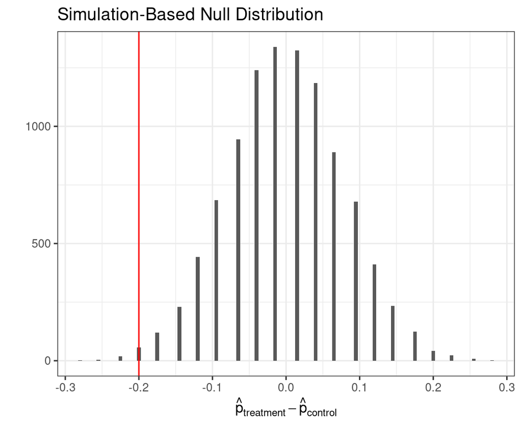

```r
# Using the permuation data, plot stat
ggplot(opp_perm, aes(x = stat)) +
  # Add a histogram layer with binwidth 0.005
  geom_histogram(binwidth = 0.005) +
  # Add a vline layer with intercept diff_obs
  geom_vline(aes(xintercept = diff_obs), color = "red") +
  theme_bw() +
  labs(x = expression(hat(p)[treatment] - hat(p)[control]), y = "", title = "Simulation-Based Null Distribution")
```

## 1.3 Summarizing opportunity cost

Now that you’ve created the randomization distribution, you’ll use it to assess whether the observed difference in proportions is consistent with the null difference. You will measure this consistency (or lack thereof) with a p-value, or the proportion of permuted differences less than or equal to the observed difference.

The permuted dataset and the original observed statistic are available in your workspace as `opp_perm` and `diff_obs` respectively.

The p-value (which represents how often a null value is more extreme) is calculated by counting the number of null values which are less than the original difference.

- First `visualize` the sampling distribution of the permuted statistics. Use `shade_p_value()` to indicate the place where `obs_stat = diff_obs`, and coloring in values below with the command `direction = "less"`.

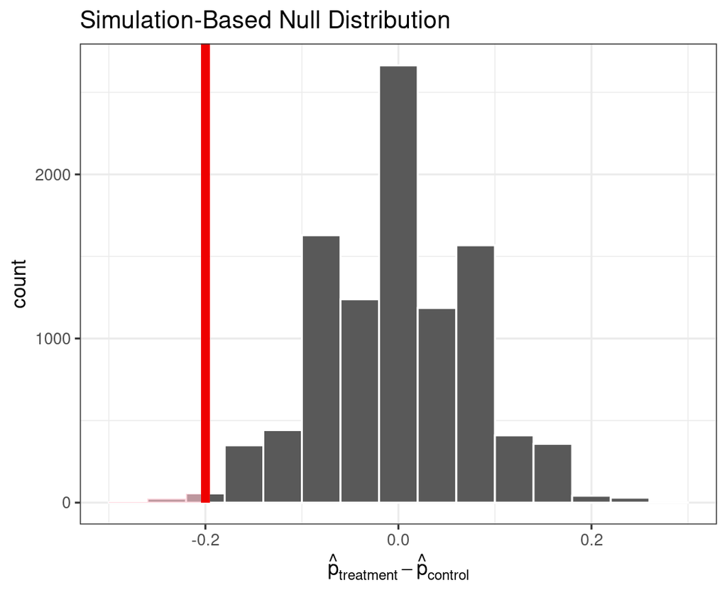

```r
# Visualize the statistic
opp_perm %>%
  visualize() +
  shade_p_value(obs_stat = diff_obs, direction = "less") +
  theme_bw() +
  labs(x = expression(hat(p)[treatment] - hat(p)[control]))
```

- Compute the p-value.

```r
# Calculate the p-value using `get_p_value`
opp_perm %>%
  get_p_value(obs_stat = diff_obs, direction = "less")
```

```
# A tibble: 1 × 1
  p_value
    <dbl>
1  0.0082
```

```r
# or
opp_perm %>%
  summarize(p_value = mean(stat <= diff_obs))
```

```
# A tibble: 1 × 1
  p_value
    <dbl>
1  0.0082
```

The small p-value indicates that the observed data are inconsistent with the null hypothesis. We should reject the null claim and conclude that financial advice does affect the likelihood of purchase.

# 2 Using a for loop

```r
opportunity <- opportunity %>%
  mutate(decisionN = ifelse(decision == "buyDVD", 1, 0))
head(opportunity)
```

```
  decision   group decisionN
1   buyDVD control         1
2   buyDVD control         1
3   buyDVD control         1
4   buyDVD control         1
5   buyDVD control         1
6   buyDVD control         1
```

- Create the simulation based permutation distribution using a for loop.

```r
set.seed(16)
reps <- 10^4
stat <- numeric(reps)
for(i in 1:reps){
  stat[i] <- diff(tapply(opportunity$decisionN,
                         sample(opportunity$group), mean))
}
```

- Visualize the permuted differences with the base R function `hist()`.

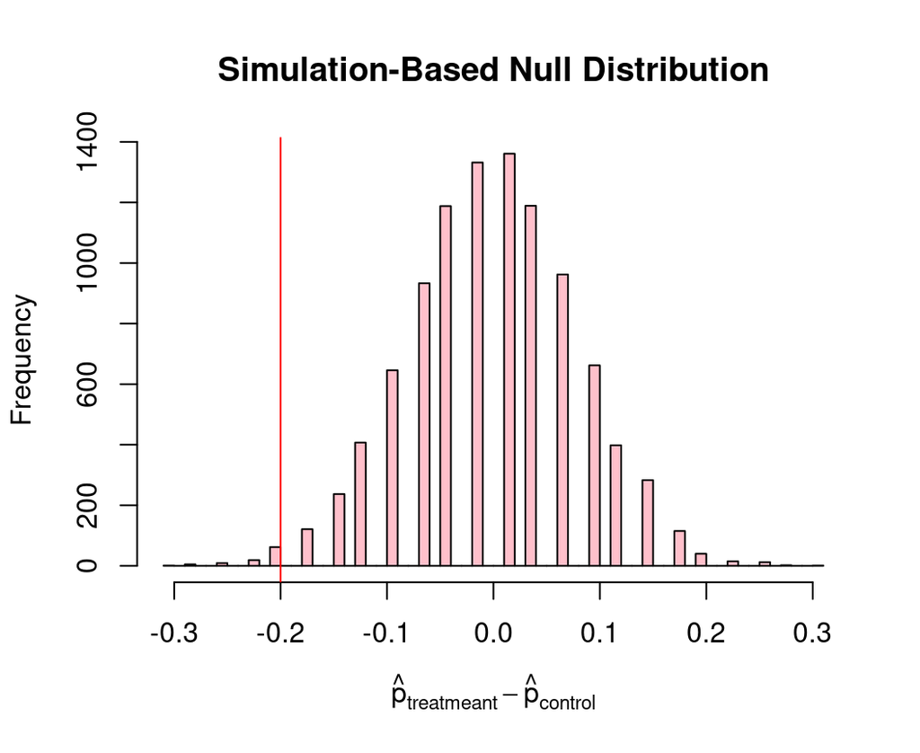

```r
hist(stat, breaks = "Scott",
     xlab = expression(hat(p)[treatmeant] - hat(p)[control]),
     col = "pink", main = "Simulation-Based Null Distribution")
abline(v = diff_obs, col = "red")
```

- Visualize the permuted differences with `ggplot2` functions.

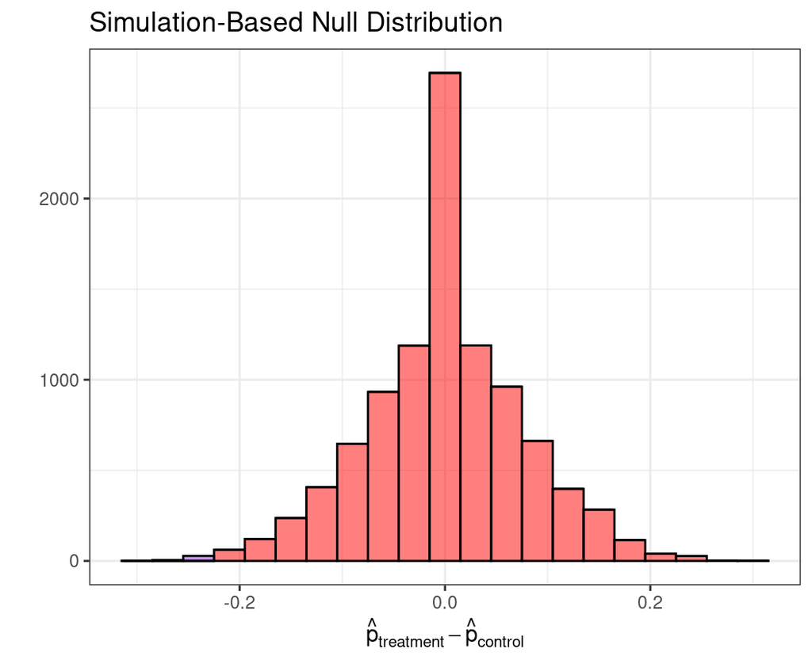

```r
DF <- data.frame(stat = stat)
ggplot(data = DF, aes(x = stat)) +
  geom_histogram(aes(fill = stat >= diff_obs), binwidth = .03, alpha = 0.5, color = "black") +
  guides(fill = "none") +
  scale_fill_manual(values = c("purple", "red")) +
  labs(x = expression(hat(p)[treatment] - hat(p)[control]),
       y = "",
       title = "Simulation-Based Null Distribution") +
  theme_bw()
```

- Compute the p-value.

```r
(pvalue <- mean(stat <= diff_obs))
```

```
[1] 0.0096
```